# plot exercise

kangminji

2021 4 28

1. mpg 데이터의 cty(도시 연비)와 hwy(고속도로 연비) 간에 어떤 관계가 있는지 알아보려고 합니다. x축은 cty, y축은 hwy로 된 산점도를 만들어 보세요.

```r
library(ggplot2)
library(dplyr)
mpg %>% names
```

```
##  [1] "manufacturer" "model"        "displ"        "year"         "cyl"
##  [6] "trans"        "drv"          "cty"          "hwy"          "fl"
## [11] "class"
```

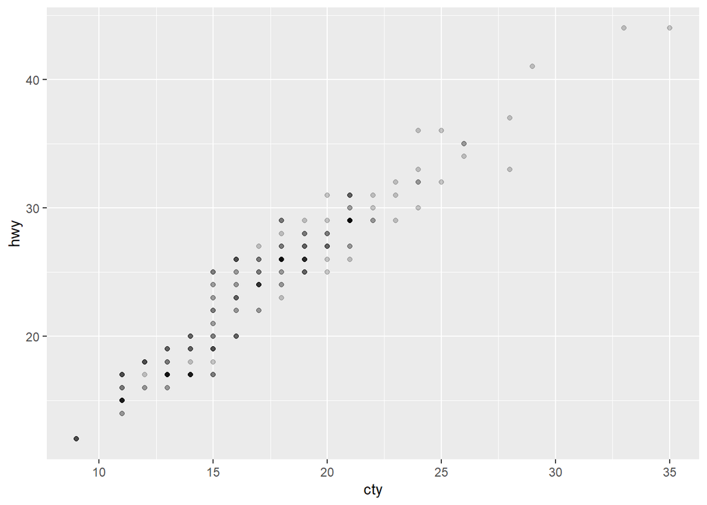

```r
ggplot(mpg,aes(cty,hwy))+
  geom_point(alpha=0.2)
```

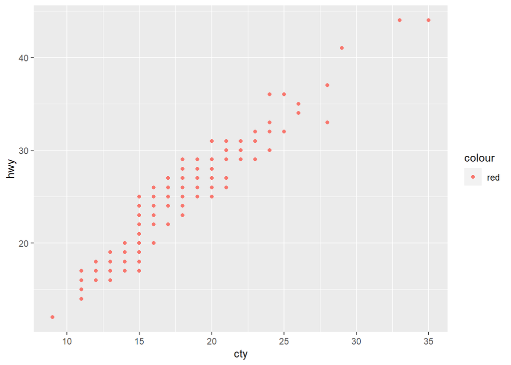

```r
mpg %>%
  ggplot(aes(x=cty,y=hwy,col='red'))+
  geom_point()
```

```r
midwest %>% str()
```

```
## tibble[,28] [437 x 28] (S3: tbl_df/tbl/data.frame)
##  $ PID                 : int [1:437] 561 562 563 564 565 566 567 568 569 570 ...
##  $ county              : chr [1:437] "ADAMS" "ALEXANDER" "BOND" "BOONE" ...
##  $ state               : chr [1:437] "IL" "IL" "IL" "IL" ...
##  $ area                : num [1:437] 0.052 0.014 0.022 0.017 0.018 0.05 0.017 0.027 0.024 0.058 ...
##  $ poptotal            : int [1:437] 66090 10626 14991 30806 5836 35688 5322 16805 13437 173025 ...
##  $ popdensity          : num [1:437] 1271 759 681 1812 324 ...
##  $ popwhite            : int [1:437] 63917 7054 14477 29344 5264 35157 5298 16519 13384 146506 ...
##  $ popblack            : int [1:437] 1702 3496 429 127 547 50 1 111 16 16559 ...
##  $ popamerindian       : int [1:437] 98 19 35 46 14 65 8 30 8 331 ...
##  $ popasian            : int [1:437] 249 48 16 150 5 195 15 61 23 8033 ...
##  $ popother            : int [1:437] 124 9 34 1139 6 221 0 84 6 1596 ...
##  $ percwhite           : num [1:437] 96.7 66.4 96.6 95.3 90.2 ...
##  $ percblack           : num [1:437] 2.575 32.9 2.862 0.412 9.373 ...
##  $ percamerindan       : num [1:437] 0.148 0.179 0.233 0.149 0.24 ...
##  $ percasian           : num [1:437] 0.3768 0.4517 0.1067 0.4869 0.0857 ...
##  $ percother           : num [1:437] 0.1876 0.0847 0.2268 3.6973 0.1028 ...
##  $ popadults           : int [1:437] 43298 6724 9669 19272 3979 23444 3583 11323 8825 95971 ...
##  $ perchsd             : num [1:437] 75.1 59.7 69.3 75.5 68.9 ...
##  $ percollege          : num [1:437] 19.6 11.2 17 17.3 14.5 ...
##  $ percprof            : num [1:437] 4.36 2.87 4.49 4.2 3.37 ...
##  $ poppovertyknown     : int [1:437] 63628 10529 14235 30337 4815 35107 5241 16455 13081 154934 ...
##  $ percpovertyknown    : num [1:437] 96.3 99.1 95 98.5 82.5 ...
##  $ percbelowpoverty    : num [1:437] 13.15 32.24 12.07 7.21 13.52 ...
##  $ percchildbelowpovert: num [1:437] 18 45.8 14 11.2 13 ...
##  $ percadultpoverty    : num [1:437] 11.01 27.39 10.85 5.54 11.14 ...
##  $ percelderlypoverty  : num [1:437] 12.44 25.23 12.7 6.22 19.2 ...
##  $ inmetro             : int [1:437] 0 0 0 1 0 0 0 0 0 1 ...
##  $ category            : chr [1:437] "AAR" "LHR" "AAR" "ALU" ...
```

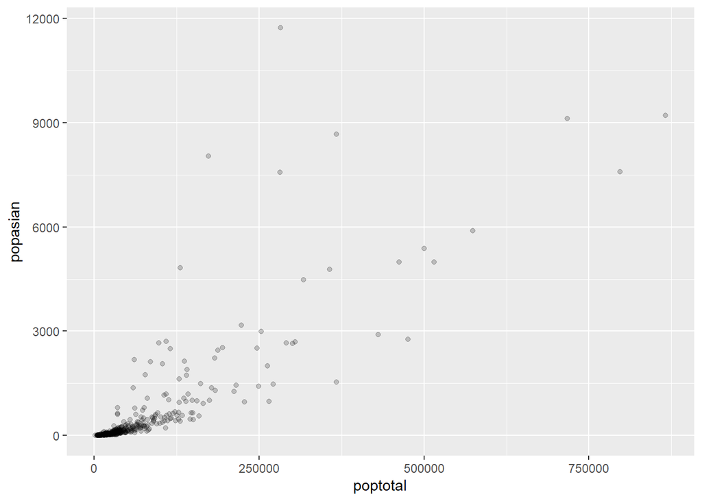

```r
midwest %>%
  filter(poptotal<=500000|popasian<=10000) %>%
  ggplot(aes(poptotal,popasian))+
  geom_point(alpha=0.2)
```

3. 어떤 회사에서 생산한 “suv” 차종의 도시 연비가 높은지 알아보려고 합니다. “suv” 차종을 대상으로 평균 cty(도시 연비)가 가장 높은 회사 다섯 곳을 막대 그래프로 표현해 보세요. 막대는 연비가 높은 순으로 정렬하세요.

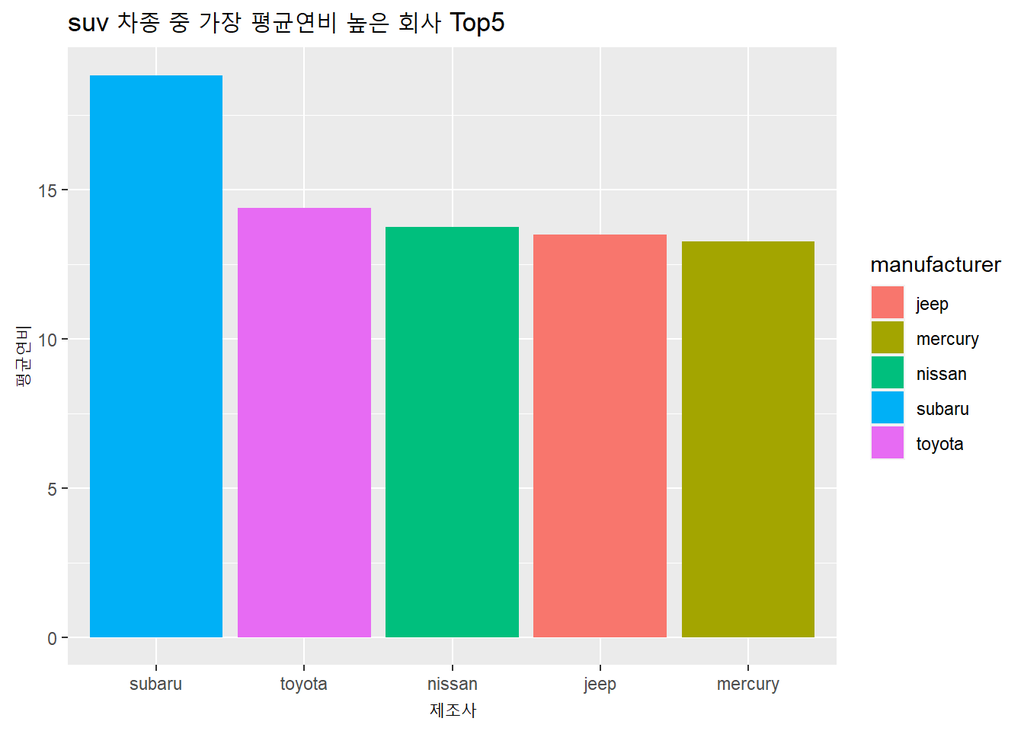

```r
mpg2<- mpg %>%
  filter(class=='suv') %>%
  group_by(manufacturer) %>%
  summarise(avg_cty=mean(cty)) %>%
  arrange(desc(avg_cty)) %>%
  head(5)
ggplot(mpg2, aes(x=reorder(manufacturer, -avg_cty), y=avg_cty)) +
  geom_bar(stat='identity',aes(fill=manufacturer)) +
  labs(title = "suv 차종 중 가장 평균연비 높은 회사 Top5", x = "제조사", y = "평균연비")
```

4. 자동차 중에서 어떤 class(자동차 종류)가 가장 많은지 알아보려고 합니다.

자동차 종류별 빈도를 표현한 막대 그래프를 만들어 보세요.

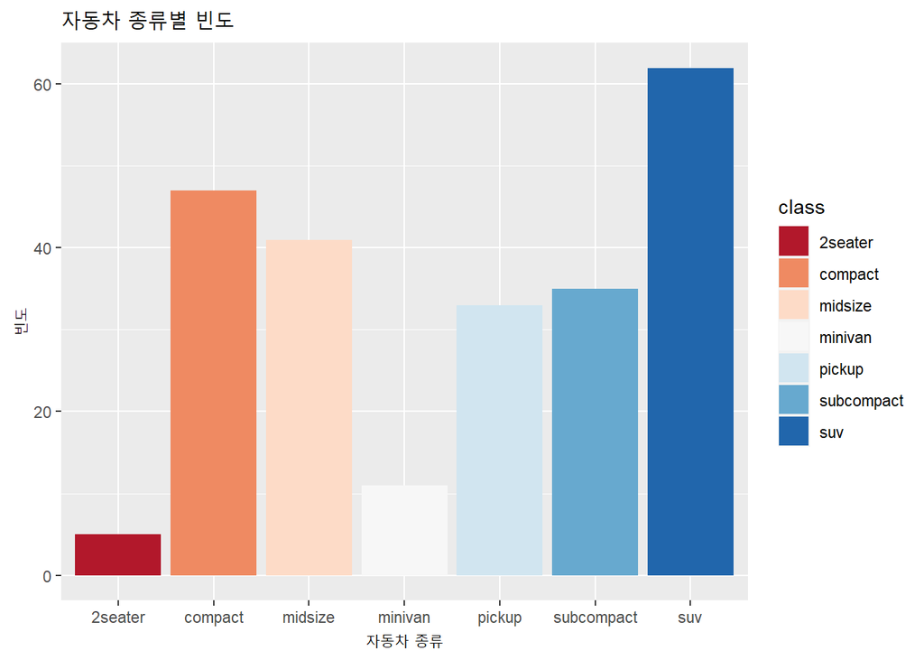

```r
ggplot(mpg, aes(class))+
  geom_bar(stat='count',aes(fill=class))+
  scale_fill_brewer(palette='RdBu') +
  ggtitle("자동차 종류별 빈도") +labs(x="자동차 종류", y="빈도")
```

5. economics 데이터를 이용해서 psavert(개인 저축률)가 시간에 따라서 어떻게 변해왔는지 알아보려고 합니다. 시간에 따른 개인 저축률의 변화를 나타낸 시계열 그래프를 만들어 보세요.

```r
economics %>% head()
```

```
## # A tibble: 6 x 6
##   date         pce    pop psavert uempmed unemploy
##   <date>     <dbl>  <dbl>   <dbl>   <dbl>    <dbl>
## 1 1967-07-01  507. 198712    12.6     4.5     2944
## 2 1967-08-01  510. 198911    12.6     4.7     2945
## 3 1967-09-01  516. 199113    11.9     4.6     2958
## 4 1967-10-01  512. 199311    12.9     4.9     3143
## 5 1967-11-01  517. 199498    12.8     4.7     3066
## 6 1967-12-01  525. 199657    11.8     4.8     3018
```

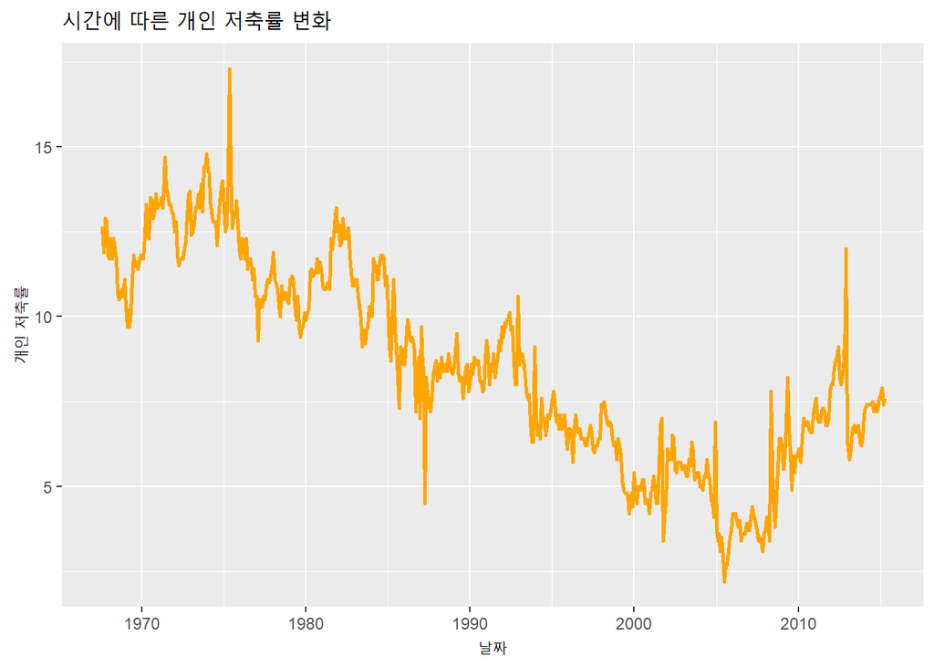

```r
economics %>%
ggplot(aes(date,psavert))+geom_line(linetype="solid",color="orange",size=1)+
  ggtitle("시간에 따른 개인 저축률 변화") +labs(x="날짜", y="개인 저축률")
```

6. class(자동차 종류)가 “compact”, “subcompact”, “suv”인 자동차의 cty(도시 연비)가 어떻게 다른지 비교해보려고 합니다. 세 차종의 cty를 나타낸 상자 그림을 만들어보세요.

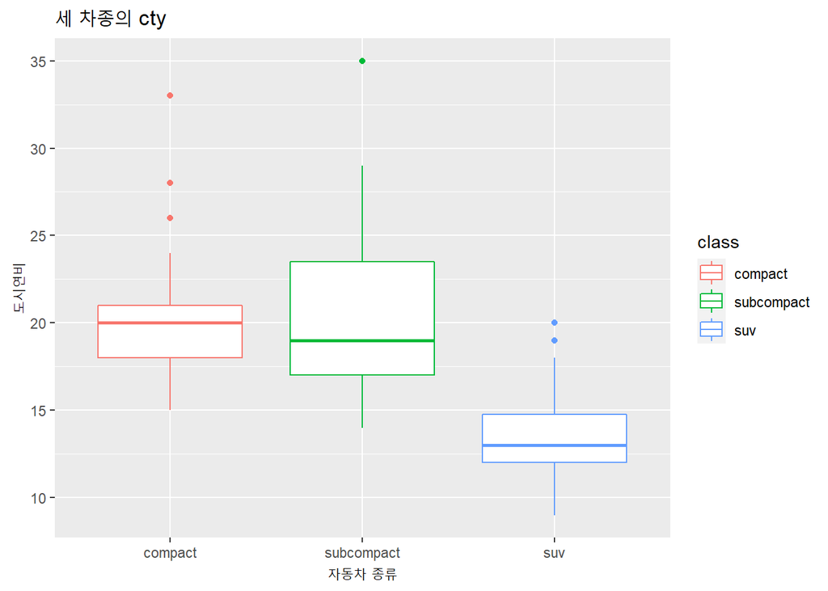

```r
m_c <- mpg %>%
  filter(class %in% c("compact","subcompact","suv"))
m_c %>%
  ggplot(aes(class, cty, col=class)) +
  geom_boxplot()+
  ggtitle("세 차종의 cty") +labs(x="자동차 종류", y="도시연비")
```

7. Diamonds 데이터 셋을 이용하여 다음 문제를 해결하세요.

단, 컬러, 제목, x축, y축 등 그래프를 예쁘게 작성하세요.

1. cut의 돗수를 보여주는 그래프를 작성하세요.

```r
diamonds %>% str()
```

```
## tibble[,10] [53,940 x 10] (S3: tbl_df/tbl/data.frame)
##  $ carat  : num [1:53940] 0.23 0.21 0.23 0.29 0.31 0.24 0.24 0.26 0.22 0.23 ...
##  $ cut    : Ord.factor w/ 5 levels "Fair"<"Good"<..: 5 4 2 4 2 3 3 3 1 3 ...
##  $ color  : Ord.factor w/ 7 levels "D"<"E"<"F"<"G"<..: 2 2 2 6 7 7 6 5 2 5 ...
##  $ clarity: Ord.factor w/ 8 levels "I1"<"SI2"<"SI1"<..: 2 3 5 4 2 6 7 3 4 5 ...
##  $ depth  : num [1:53940] 61.5 59.8 56.9 62.4 63.3 62.8 62.3 61.9 65.1 59.4 ...
##  $ table  : num [1:53940] 55 61 65 58 58 57 57 55 61 61 ...
##  $ price  : int [1:53940] 326 326 327 334 335 336 336 337 337 338 ...
##  $ x      : num [1:53940] 3.95 3.89 4.05 4.2 4.34 3.94 3.95 4.07 3.87 4 ...
##  $ y      : num [1:53940] 3.98 3.84 4.07 4.23 4.35 3.96 3.98 4.11 3.78 4.05 ...
##  $ z      : num [1:53940] 2.43 2.31 2.31 2.63 2.75 2.48 2.47 2.53 2.49 2.39 ...
```

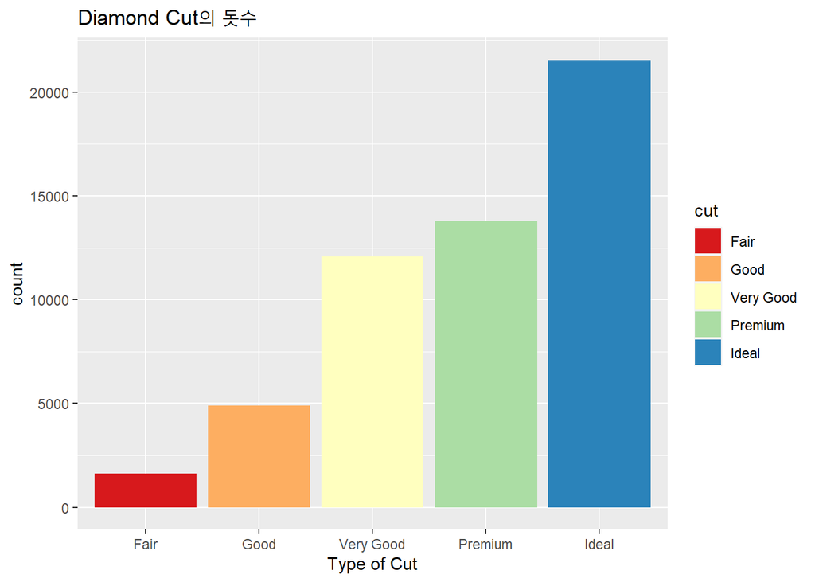

```r
diamonds %>%
  ggplot(aes(cut))+
  geom_bar(stat='count',aes(fill=cut))+
  scale_fill_brewer(palette='Spectral')+
  ggtitle("Diamond Cut의 돗수") + xlab("Type of Cut") + ylab("count")
```

2. cut에 따른 가격의 변화를 보여주는 그래프를 작성하세요.

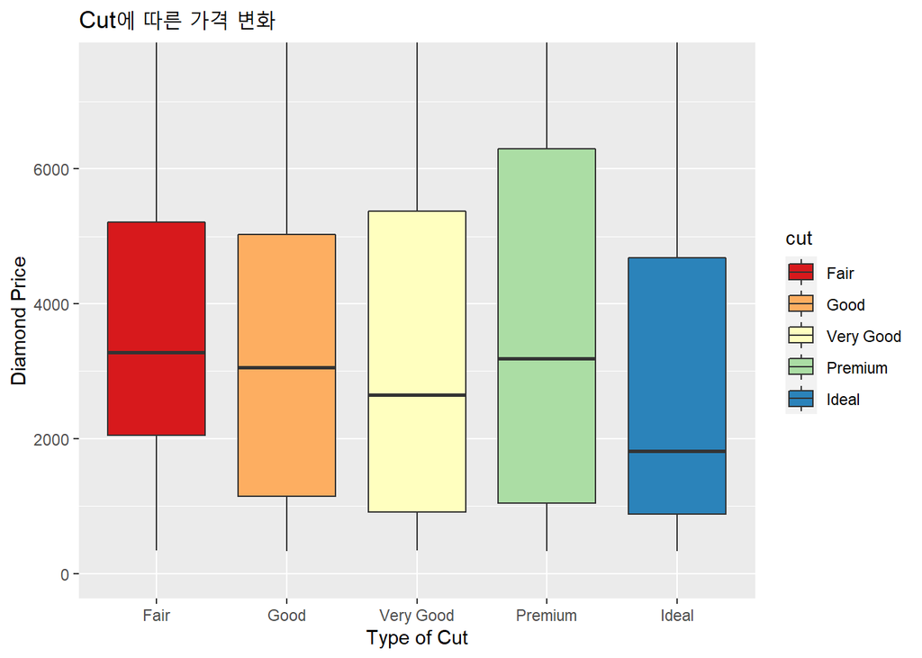

```r
ggplot(diamonds, aes(cut, price, fill=cut)) +
  geom_boxplot() +
  scale_fill_brewer(palette='Spectral')+
  ggtitle("Cut에 따른 가격 변화") + xlab("Type of Cut") + ylab("Diamond Price") + coord_cartesian(ylim=c(0,7500))
```

3. cut과 color에 따른 가격의 변화를 보여주는 그래프를 작성하세요.

```r
m_p <- diamonds %>%
  group_by(cut,color) %>%
  summarise(m_p=mean(price))
```

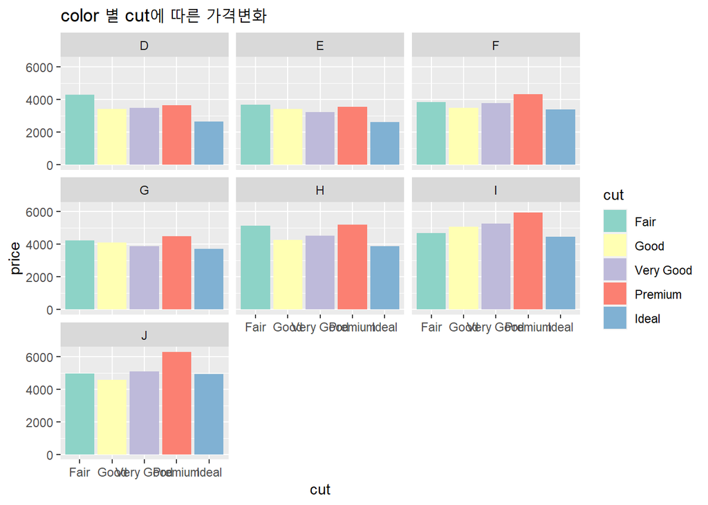

```r
ggplot(m_p, aes(cut, m_p)) +
  geom_bar(stat='identity',aes(fill=cut)) +
  scale_fill_brewer(palette='Set3') +
  ggtitle("color 별 cut에 따른 가격변화") +
  labs(x="cut", y="price")+
  facet_wrap(~color)                 #color별로 나눠줌
```